# Probability Review

Biostat 212A, Statistical Learning A

Author

Dr. Jin Zhou @ UCLA

Published

January 11, 2026

Credit: This note is compiled using content from multiple sources

- [Introduction to Probability](https://dlsun.github.io/probability/), [git repo](https://github.com/dlsun/probability) by Dennis Sun
- [An Introduction to Probability and Simulation](https://bookdown.org/kevin_davisross/probsim-book/ce.html) by Kevin Ross
- [Probability : An Introduction](https://search.library.ucla.edu/permalink/01UCS_LAL/192ecse/cdi_askewsholts_vlebooks_9780191019937) by Geoffrey Grimmett, Dominic Welsh, and Professor of Mathematics (Retired) Dominic Welsh
- [Deeplearning book](https://www.deeplearningbook.org/contents/prob.html)

# 1 Conditional distribution

- For **discrete** random variables $X$ and $Y$, the **conditional probability mass function (p.m.f.)** of $Y$ given $X$ is defined as
  $$\begin{equation}
  f_{Y|X}(y|x) \overset{\text{def}}{=} P(Y = y | X = x) = \frac{f(x, y)}{f_X(x)}.
  \end{equation}$$
  - Lesson 20 of [Introduction to Probability, by Dr. Dennis Sun](https://dlsun.github.io/probability/) for more details and examples.
- Let X and Y be two **continuous** random variables with joint probability density function (p.d.f) $f_{X, Y}$ and marginal pdfs $f_X$, $f_Y$. For any fixed $x$, $f_X(x)>0$, the **conditional probability density function (p.d.f.)** of $Y$ given $X$ is defined as
  $$\begin{equation}
  f_{Y|X}(y|x) \overset{\text{def}}{=} \frac{f(x, y)}{f_X(x)}.
  \end{equation}$$
- To emphasize, the notation $f_{Y|X}(y|x)$ represents a conditional distribution of the random variable $Y$ for a fixed value $x$ of the random variable $X$. In the expression $f_{Y|X}(y|x)$, $x$ is treated like a constant and $y$ is treated as the variable.
- Notice that the pdfs satisfy
  $$\text{conditional} =\frac{\text{joint}}{\text{marginal}}$$
- Conditional distributions can be obtained from a joint distribution by slicing and renormalizing. A nice graphic example is shown here: Lesson 20 of [Introduction to Probability, by Dr. Dennis Sun](https://dlsun.github.io/probability/).

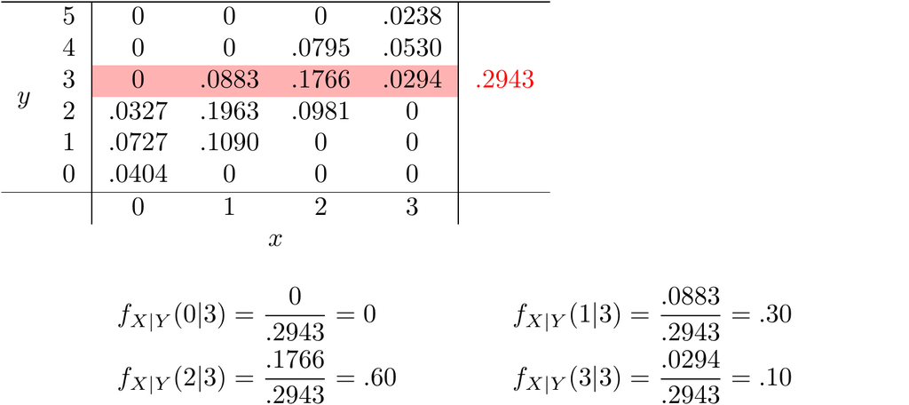

- This is not one “conditional distribution of $Y$ given $X$”, but rather a family of conditional distributions of $Y$ given different values of $X$.
- Be sure to distinguish between joint, conditional, and marginal distributions.
  - The **joint** distribution is a distribution on $(X, Y)$ pairs. A mathematical expression of a joint distribution is a function of both values of $X$ and values of $Y$ . In particular, a joint pdf $f_{X, Y}$ is a function of both values of $X$ and values of $Y$. Pay special attention to the possible values; the possible values of one variable might be restricted by the value of the other.
  - The **conditional** distribution of $Y$ given $X = x$ is a distribution on $Y$ values (among $(X, Y)$ pairs with a fixed value of $X = x$). A mathematical expression of a conditional distribution will involve both $x$ and $y$, but $x$ is treated like a fixed constant and $y$ is treated as the variable. In particular, a conditional pdf $f_{Y|X}$ is a function of values of $Y$ for a fixed value of $x$, treat $x$ like a constant and $y$ as the variable. **Note**: the possible values of $Y$ might depend on the value of $x$, but $x$ is treated like a constant.
  - The **marginal** distribution of $Y$ is a distribution on $Y$ values only, regardless of the value of $X$. A mathematical expression of a marginal distribution will have only values of the single variable in it; for example, an expression for the marginal distribution of $Y$ will only have $y$ in it (no $x$, not even in the possible values). In particular, a marginal pdf $f_Y$ is a function of values of $Y$ only.

# 2 Conditional expection

Conditioning on the value of a random variable $X$ in general changes the distribution of another random variable $Y$. If a distribution changes, its summary characteristics like expected value and variance can change too.

- The **conditional expectation** (a.k.a. **conditional expected value** a.k.a. **conditional mean**), of a random variable $Y$ given the event $\{X = x\}$, defined on a probability space with measure $P$, is a number denoted $\mathbf{E}(Y|X = x)$ representing the probability-weighted average value of $Y$, where the weights are determined by the **conditional distribution** of $Y$ given $X = x$.
  - $\textbf{Discrete}$ $(X, Y)$ with conditional pmf $p_{Y|X}$:
    $$E(Y|X = x) = \sum_{y} y p_{Y|X} (y|x)$$
  - $\textbf{Continuous}$ $(X, Y)$ with conditional pdf $f_{Y|X}$:
    $$E(Y|X = x) = \int_{-\infty}^{\infty} y f_{Y|X} (y|x) \, dy$$

## 2.2 Linearity of conditional expected value

- Conditional expected value, whether viewed as a number $\mathbf{E}( Y | X = x)$ or as a random variable $\mathbf{E}(Y|X)$, possesses properties analogous to those of (unconditional) expected value. In particular, we have linearity of conditional expected value.
  $$\begin{align*}
  \mathbf{E}(a_1Y_1 + \ldots + a_nY_n | X = x) & = a_1\mathbf{E}(Y_1 | X = x) + \ldots + a_nE(Y_n | X = x)\\
  \mathbf{E}(a_1Y_1 + \ldots + a_nY_n | X) & = a_1\mathbf{E}(Y_1 | X = x) + \ldots + a_nE(Y_n | X)
  \end{align*}$$
  The first line above is an equality involving numbers; the second line is an equality involving random variables (i.e., functions).

## 2.3 Law of total expectation

- The law of total expectation provides a way of computing an expected value by breaking down a problem into various cases, computing the conditional expected value given each case, and then computing the overall expected value as a probability-weighted average of these case-by-case conditional expected values.
- **Law of Total Expectation (LTE)** For any two random variables $X$ and $Y$ defined on the same probability space,
  $$\mathbf{E}(Y) = \mathbf{E}(\mathbf{E}(Y|X)).$$
  - $\mathbf{E}( Y | X = x)$ is a random variable and so it has an expected value $\mathbf{E}(\mathbf{E}(Y|X))$ representing the average value of the random variable $\mathbf{E}(\mathbf{E}(Y|X))$.
  - $\mathbf{E}( Y | X = x)$ is a function of $X$ and so $\mathbf{E}(\mathbf{E}(Y|X))$ can be computed with respect to $X$. For two discrete random variables X and Y
    $$\begin{align*}
    \mathbf{E}(\mathbf{E}(Y|X)) & = \sum_{x} \mathbf{E}(Y|X = x) \mathbf{P}(X = x)\\
    & = \sum_{x} \sum_{y} y \mathbf{P}_{Y|X} (y|x) \mathbf{P}(X = x)\\
    & = \sum_{x} \sum_{y} y \mathbf{P}_{X,Y} (x, y)\\
    & = \sum_{y} y\sum_{x} \mathbf{P}_{X,Y} (x, y)\\
    & = \sum_{y} y \mathbf{P}_{Y} (y)\\
    & = \mathbf{E}(Y)
    \end{align*}$$

# 3 Excercises

Roll a fair four-sided die twice. Let $X$ be the sum of the two rolls, and let  
$Y$ be the larger of the two rolls (or the common value if a tie). We found the joint and marginal distributions of $X$ and $Y$ displayed in the table below.

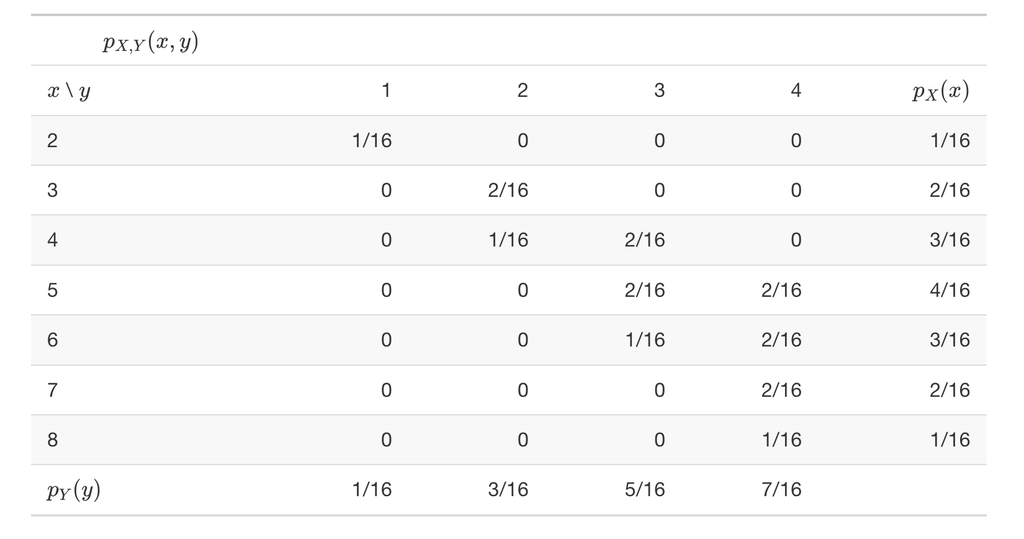

1. Find $\mathbf{E}(Y)$.
2. Find $\mathbf{E}(Y|X = 5)$.
3. Find $\mathbf{E}(Y|X = 6)$.
4. Find $\mathbf{E}(Y|X = x)$.
5. Find $\mathbf{E}(X|Y)$.
6. Find $\mathbf{E}(X|Y = y)$.